# Assigment 2

Rafael Pulido

3/10/2017

## Loading and preprocessing the data

```r
data <- read.csv("activity.csv")
library(knitr)
library(ggplot2)
library(dplyr)
library(xtable)
library(lattice)
data$date <- as.Date(as.character(data$date))
data$steps <- as.numeric(data$steps)
```

## What is mean total number of steps taken per day?

You can a see a histogram that shows the number of steps taken each day along the period of study.

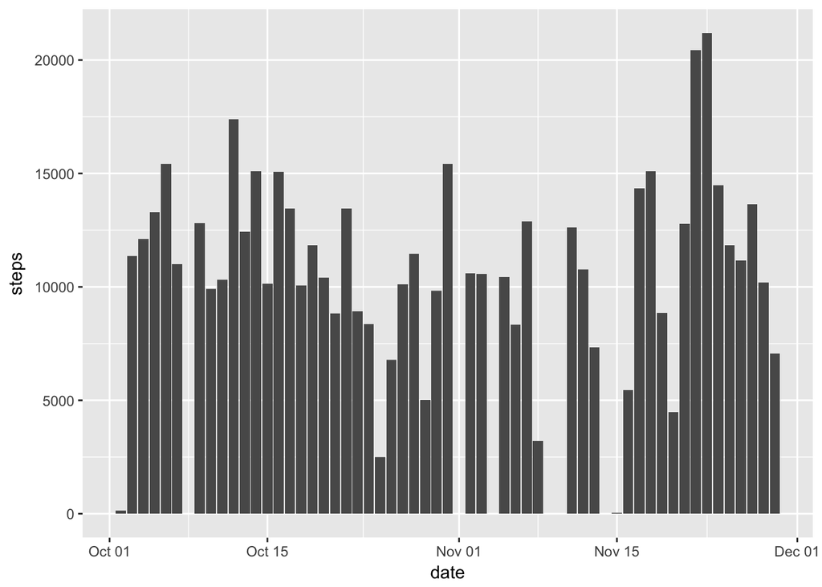

```r
his <- ggplot(data, aes(date, steps))
his  + geom_bar(stat = "identity", na.rm = TRUE)
```

You can also see a table that describe the mean and median for each day of study.

```r
data2 <- group_by(data, date)
kable(summarize(data2, mean = mean(steps, na.rm = FALSE), median = median(steps, na.rm = FALSE)), digits = 2)
```

| date | mean | median |
| --- | --- | --- |
| 2012-10-01 | NA | NA |
| 2012-10-02 | 0.44 | 0 |
| 2012-10-03 | 39.42 | 0 |
| 2012-10-04 | 42.07 | 0 |
| 2012-10-05 | 46.16 | 0 |
| 2012-10-06 | 53.54 | 0 |
| 2012-10-07 | 38.25 | 0 |
| 2012-10-08 | NA | NA |
| 2012-10-09 | 44.48 | 0 |
| 2012-10-10 | 34.38 | 0 |
| 2012-10-11 | 35.78 | 0 |
| 2012-10-12 | 60.35 | 0 |
| 2012-10-13 | 43.15 | 0 |
| 2012-10-14 | 52.42 | 0 |
| 2012-10-15 | 35.20 | 0 |
| 2012-10-16 | 52.38 | 0 |
| 2012-10-17 | 46.71 | 0 |
| 2012-10-18 | 34.92 | 0 |
| 2012-10-19 | 41.07 | 0 |
| 2012-10-20 | 36.09 | 0 |
| 2012-10-21 | 30.63 | 0 |
| 2012-10-22 | 46.74 | 0 |
| 2012-10-23 | 30.97 | 0 |
| 2012-10-24 | 29.01 | 0 |
| 2012-10-25 | 8.65 | 0 |
| 2012-10-26 | 23.53 | 0 |
| 2012-10-27 | 35.14 | 0 |
| 2012-10-28 | 39.78 | 0 |
| 2012-10-29 | 17.42 | 0 |
| 2012-10-30 | 34.09 | 0 |
| 2012-10-31 | 53.52 | 0 |
| 2012-11-01 | NA | NA |
| 2012-11-02 | 36.81 | 0 |
| 2012-11-03 | 36.70 | 0 |
| 2012-11-04 | NA | NA |
| 2012-11-05 | 36.25 | 0 |
| 2012-11-06 | 28.94 | 0 |
| 2012-11-07 | 44.73 | 0 |
| 2012-11-08 | 11.18 | 0 |
| 2012-11-09 | NA | NA |
| 2012-11-10 | NA | NA |
| 2012-11-11 | 43.78 | 0 |
| 2012-11-12 | 37.38 | 0 |
| 2012-11-13 | 25.47 | 0 |
| 2012-11-14 | NA | NA |
| 2012-11-15 | 0.14 | 0 |
| 2012-11-16 | 18.89 | 0 |
| 2012-11-17 | 49.79 | 0 |
| 2012-11-18 | 52.47 | 0 |
| 2012-11-19 | 30.70 | 0 |
| 2012-11-20 | 15.53 | 0 |
| 2012-11-21 | 44.40 | 0 |
| 2012-11-22 | 70.93 | 0 |
| 2012-11-23 | 73.59 | 0 |
| 2012-11-24 | 50.27 | 0 |
| 2012-11-25 | 41.09 | 0 |
| 2012-11-26 | 38.76 | 0 |
| 2012-11-27 | 47.38 | 0 |
| 2012-11-28 | 35.36 | 0 |
| 2012-11-29 | 24.47 | 0 |
| 2012-11-30 | NA | NA |

## What is the average daily activity pattern?

To observe the activity along the day by intervals, a time series plot was created as follows.

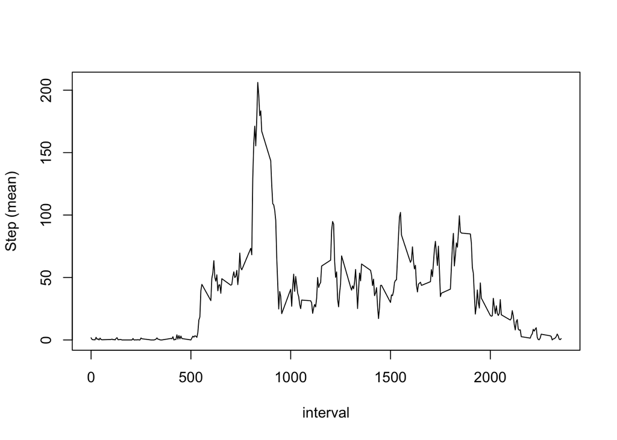

```r
stepsinterval <- aggregate(steps ~ interval , data = data, FUN = mean)
with(stepsinterval, plot(interval, steps, type = "l", main ="", ylab = "Step (mean)"))
```

```r
steps <- max(stepsinterval$steps)
interval <- stepsinterval[stepsinterval$steps == steps, 1]
```

The interval with the highest number of steps on averages is the 835 interval with 206.1698113 steps on average.